# Electronic healthcare data analysis for medication adherence with AdhereR

Alexandra L. Dima, Samuel S. Allemann & Dan Dediu

2018-11-26

## Introduction

`AdhereR` is an R package that aims to facilitate the computing of adherence from EHD, as well as the transparent reporting of the chosen calculations. It contains a set of `R` `S3` *classes* and *functions* that *compute*, *summarize* and *plot* various estimates of adherence.

This tutorial aims to introduce researchers to the principles of EHD preparation required to estimate adherence with the AdhereR package. It uses example data to illustrate the various decisions required and their impact on estimates, starting with the visualization of medication events, computation of persistence (treatment episode length), and computation of adherence. It also includes some practical exercises.

Please contact us with suggestions, bug reports, comments (or even just to share your experiences using the package) either by e-mail (to Dan ddediu@gmail.com, Alexandra alexadima@gmail.com or Samuel samuel.allemann@gmx.ch) or using GitHub’s reporting mechanism at our repository https://github.com/ddediu/AdhereR, which contains the full source code of the package.

## Data preparation and example dataset

`AdhereR` requires a dataset of medication events over a follow-up window (FUW) of sufficient length in relation to the recommended treatment duration. To our knowledge, no research has been performed to date on the relationship between FUW length and recommended treatment duration. `AdhereR` offers the opportunity for answering such methodological questions, but we would hypothesize that the FUW duration also depends on the duration of medication events (shorter durations would allow shorter FUW windows to be informative).

The minimum necessary dataset includes 3 variables for each medication event: *patient unique identifier*, *event date*, and *duration*. *Daily dosage* and *medication type* are optional.`AdhereR` is thus designed to use datasets that have already been extracted from EHD and prepared for calculation. The preliminary data preparation depend to a large extent on the specific database used and the type of medication and research design. Several general guidelines can be consulted (Arnet *et al.*, 2016; Peterson *et al.*, 2007), as well as database-specific documentation. In essence, these steps should entail:

- selecting medication events applicable to the research question based on relevant time intervals and medication codes,
- coding medication type depending on clinical considerations, for example coding different therapeutic classes in polypharmacy studies,
- calculate, if necessary, medication event durations
- checking plausible values and correcting any deviations,
- handling missing data.

Oftentimes, datasets can be large with hundreds of thousands or even millions of rows. Provided that working memory is big enough to hold the entire dataset, R can handle it. Manipulating these large datasets with the standard R libraries can be a hassle. We will use the package `data.table`, which usually requires less memory and is faster than the standard `data.frame` format. In this example we will use however three related datasets that describe the prescribing, dispensing, and hospitalisation events for 16 patients over a 2-year period. These data have been already cleaned to some extent, and we will illustrate how to perform the last steps of the data cleaning and preparation and then calculate adherence estimates.

```r
# Load the AdhereR and data.table libraries (and install if not already installed):
if (!require("AdhereR")) install.packages("AdhereR")
library(AdhereR)
if (!require("data.table")) install.packages("data.table")
library(data.table)
if (!require("shinyWidgets")) install.packages("shinyWidgets")
library(shinyWidgets)
```

### Data cleaning

First, we have to make sure that the data are in the right format. We can use the function `str()` to check the format of our variables and `summary()` for a first plausibility check.

```r
# Check format of the datasets included in AdhereR:
str(durcomp.prescribing)
```

```
## Classes 'data.table' and 'data.frame':   1502 obs. of  8 variables:
##  $ ID            : num  1 1 1 1 1 1 1 1 1 1 ...
##  $ DATE.PRESC    : Date, format: "2056-12-08" "2057-02-23" ...
##  $ VISIT         : num  0 1 2 3 4 5 4 5 1 2 ...
##  $ ATC.CODE      : chr  "A09AA02" "A09AA02" "A09AA02" "A09AA02" ...
##  $ FORM          : chr  "ORAL FORM" "ORAL FORM" "ORAL FORM" "ORAL FORM" ...
##  $ UNIT          : chr  "UI" "UI" "UI" "UI" ...
##  $ PRESC.DURATION: num  NA NA NA NA NA NA NA NA NA NA ...
##  $ DAILY.DOSE    : num  36000 86000 86000 86000 86000 86000 20 20 100 100 ...
##  - attr(*, ".internal.selfref")=<externalptr>
##  - attr(*, "sorted")= chr "ID"
```

```r
str(durcomp.dispensing)
```

```
## Classes 'data.table' and 'data.frame':   1794 obs. of  6 variables:
##  $ ID        : num  1 1 1 1 1 1 1 1 1 1 ...
##  $ DATE.DISP : Date, format: "2057-01-14" "2057-03-07" ...
##  $ ATC.CODE  : chr  "A02BC05" "A02BC05" "A02BC05" "A02BC05" ...
##  $ UNIT      : chr  "MG" "MG" "MG" "MG" ...
##  $ FORM      : chr  "ORAL FORM" "ORAL FORM" "ORAL FORM" "ORAL FORM" ...
##  $ TOTAL.DOSE: num  1120 280 1120 1120 1120 1120 1120 100000 48000 40000 ...
##  - attr(*, ".internal.selfref")=<externalptr>
##  - attr(*, "sorted")= chr "ID"
```

```r
str(durcomp.hospitalisation)
```

```
## Classes 'data.table' and 'data.frame':   28 obs. of  3 variables:
##  $ ID      : int  1 1 3 3 3 3 3 3 3 4 ...
##  $ DATE.IN : Date, format: "2057-03-03" "2057-09-01" ...
##  $ DATE.OUT: Date, format: "2057-03-06" "2057-09-04" ...
##  - attr(*, ".internal.selfref")=<externalptr>
```

We can also see the entries for an example patient from each of the three datasets.

```r
# Display the first patient as pretty markdown table:
knitr::kable(durcomp.prescribing[ID == 1,], caption = "<a name=\"Table-1\"></a>**Table 1.** Prescribing events for one example patient");
```

**Table 1.** Prescribing events for one example patient

| ID | DATE.PRESC | VISIT | ATC.CODE | FORM | UNIT | PRESC.DURATION | DAILY.DOSE |
| --- | --- | --- | --- | --- | --- | --- | --- |
| 1 | 2056-12-08 | 0 | A09AA02 | ORAL FORM | UI | NA | 36000 |
| 1 | 2057-02-23 | 1 | A09AA02 | ORAL FORM | UI | NA | 86000 |
| 1 | 2057-03-03 | 2 | A09AA02 | ORAL FORM | UI | NA | 86000 |
| 1 | 2057-03-18 | 3 | A09AA02 | ORAL FORM | UI | NA | 86000 |
| 1 | 2057-09-01 | 4 | A09AA02 | ORAL FORM | UI | NA | 86000 |
| 1 | 2057-09-24 | 5 | A09AA02 | ORAL FORM | UI | NA | 86000 |
| 1 | 2057-09-01 | 4 | A02BC02 | ORAL FORM | MG | NA | 20 |
| 1 | 2057-09-24 | 5 | A02BC02 | ORAL FORM | MG | NA | 20 |
| 1 | 2057-02-23 | 1 | R03AC12 | METERED INHALER | MICROG | NA | 100 |
| 1 | 2057-03-03 | 2 | R03AC12 | METERED INHALER | MICROG | NA | 100 |
| 1 | 2057-03-18 | 3 | R03AC12 | METERED INHALER | MICROG | NA | 100 |
| 1 | 2057-09-01 | 4 | R03AC12 | METERED INHALER | MICROG | NA | 100 |
| 1 | 2057-09-24 | 5 | R03AC12 | METERED INHALER | MICROG | NA | 100 |

```r
# Display the first patient as pretty markdown table:
knitr::kable(durcomp.dispensing[ID == 1,], caption = "<a name=\"Table-2\"></a>**Table 2.** Dispensing events for one example patient");
```

**Table 2.** Dispensing events for one example patient

| ID | DATE.DISP | ATC.CODE | UNIT | FORM | TOTAL.DOSE |
| --- | --- | --- | --- | --- | --- |
| 1 | 2057-01-14 | A02BC05 | MG | ORAL FORM | 1120 |
| 1 | 2057-03-07 | A02BC05 | MG | ORAL FORM | 280 |
| 1 | 2056-10-03 | A02BC05 | MG | ORAL FORM | 1120 |
| 1 | 2056-12-03 | A02BC05 | MG | ORAL FORM | 1120 |
| 1 | 2057-08-04 | A02BC05 | MG | ORAL FORM | 1120 |
| 1 | 2058-02-09 | A02BC05 | MG | ORAL FORM | 1120 |
| 1 | 2058-04-21 | A02BC05 | MG | ORAL FORM | 1120 |
| 1 | 2058-02-09 | A11CC05 | UI | ORAL FORM | 100000 |
| 1 | 2056-10-09 | J01FG01 | MG | ORAL FORM | 48000 |
| 1 | 2056-10-21 | J01EE01 | MG | ORAL FORM | 40000 |
| 1 | 2056-10-09 | R03AC12 | MICROG | METERED INHALER | 3000 |
| 1 | 2057-01-14 | J01EE01 | MG | ORAL FORM | 24000 |
| 1 | 2057-03-07 | J01EE01 | MG | ORAL FORM | 8000 |
| 1 | 2057-05-02 | J01EE01 | MG | ORAL FORM | 16000 |
| 1 | 2057-09-15 | J01EE01 | MG | ORAL FORM | 16000 |
| 1 | 2057-12-11 | J01CR02 | MG | ORAL FORM | 12000 |
| 1 | 2056-10-09 | A09AA02 | UI | ORAL FORM | 1500000 |
| 1 | 2057-02-24 | A09AA02 | UI | ORAL FORM | 2940000 |
| 1 | 2057-05-26 | A09AA02 | UI | ORAL FORM | 1500000 |
| 1 | 2057-09-04 | A09AA02 | UI | ORAL FORM | 1500000 |
| 1 | 2058-06-03 | A09AA02 | UI | ORAL FORM | 4500000 |
| 1 | 2057-02-12 | A09AA02 | UI | ORAL FORM | 720000 |
| 1 | 2057-05-02 | A09AA02 | UI | ORAL FORM | 1440000 |
| 1 | 2056-12-10 | A09AA02 | UI | ORAL FORM | 1440000 |
| 1 | 2057-01-19 | J01CR02 | MG | ORAL FORM | 24000 |
| 1 | 2057-09-04 | A02BC02 | MG | ORAL FORM | 560 |
| 1 | 2058-06-03 | A02BC02 | MG | ORAL FORM | 560 |
| 1 | 2058-07-09 | A02BC02 | MG | ORAL FORM | 560 |
| 1 | 2057-04-13 | A02BC05 | MG | ORAL FORM | 560 |
| 1 | 2057-04-20 | A02BC05 | MG | ORAL FORM | 560 |
| 1 | 2056-08-05 | A02BC05 | MG | ORAL FORM | 1120 |
| 1 | 2057-05-26 | A02BC05 | MG | ORAL FORM | 1120 |

```r
# Display the first patient as pretty markdown table:
knitr::kable(durcomp.hospitalisation[ID == 1,], caption = "<a name=\"Table-3\"></a>**Table 3.** Hospitalisation events for one example patient");
```

**Table 3.** Hospitalisation events for one example patient

| ID | DATE.IN | DATE.OUT |
| --- | --- | --- |
| 1 | 2057-03-03 | 2057-03-06 |
| 1 | 2057-09-01 | 2057-09-04 |

We can see that the total quantity dispensed for each event is in the dispensing table (`TOTAL.DOSE`), and the daily dose is in the prescribing table (`DAILY.DOSE`); `ATC.CODE`, `UNIT` and `FORM` are in both tables; we also have dates of dispensing and prescribing events, and prescription durations. Hospitalisations are recorded one per row, with the patient ID, start and end date. We don’t have duration of supply for each dispensing event, and `AdhereR` requires a `DURATION` for each dispensing event to calculate adherence. We will have to calculate that first.

We can also see that the `DATE.DISP` column is *DATE* format, and the `ATC.CODE` and `UNIT` are in *CHARACTER* format. We can change the `DATE.DISP` to a different date format if necessary, and convert `ATC.CODE` to a factor variable. We can do this for each dataset, as follows:

```r
#prescribing dataset

durcomp.prescribing[,`:=` (DATE.PRESC = as.Date(DATE.PRESC, format = "%d.%m.%Y"), #convert Date to date format day-month-year
                          ATC.CODE = as.factor(ATC.CODE), #convert ATC-Code to factor variable
                          UNIT = as.factor(UNIT) #convert UNIT to factor variable
)]

# PRACTICAL EXERCISE 1:

# do the same changes for the dispensing dataset:

####your code here####

durcomp.dispensing[,`:=` (DATE.DISP = as.Date(DATE.DISP, format = "%d.%m.%Y"), #convert Date to date format day-month-year
                   ATC.CODE = as.factor(ATC.CODE), #convert ATC-Code to factor variable
                   UNIT = as.factor(UNIT) #convert UNIT to factor variable
)]

# Check format of variables:
str(durcomp.dispensing)
```

```
## Classes 'data.table' and 'data.frame':   1794 obs. of  6 variables:
##  $ ID        : num  1 1 1 1 1 1 1 1 1 1 ...
##  $ DATE.DISP : Date, format: "2057-01-14" "2057-03-07" ...
##  $ ATC.CODE  : Factor w/ 49 levels "A02BC01","A02BC02",..: 3 3 3 3 3 3 3 13 26 24 ...
##  $ UNIT      : Factor w/ 3 levels "MG","MICROG",..: 1 1 1 1 1 1 1 3 1 1 ...
##  $ FORM      : chr  "ORAL FORM" "ORAL FORM" "ORAL FORM" "ORAL FORM" ...
##  $ TOTAL.DOSE: num  1120 280 1120 1120 1120 1120 1120 100000 48000 40000 ...
##  - attr(*, ".internal.selfref")=<externalptr>
##  - attr(*, "sorted")= chr "ID"
```

```r
# Check summary of variables:
summary(durcomp.dispensing)
```

```
##        ID           DATE.DISP             ATC.CODE       UNIT
##  Min.   : 1.000   Min.   :2056-07-01   A09AA02:247   MG    :1030
##  1st Qu.: 7.000   1st Qu.:2056-12-24   A11HA03:160   MICROG: 209
##  Median :10.000   Median :2057-06-15   R03AC02:132   UI    : 555
##  Mean   : 9.666   Mean   :2057-06-23   J01FA10:121
##  3rd Qu.:14.000   3rd Qu.:2057-12-24   A11CC05:108
##  Max.   :16.000   Max.   :2058-07-12   A02BC05: 89
##                                        (Other):937
##      FORM             TOTAL.DOSE
##  Length:1794        Min.   :       10
##  Class :character   1st Qu.:     4500
##  Mode  :character   Median :    20000
##                     Mean   :  2921396
##                     3rd Qu.:    78750
##                     Max.   :120000000
##
```

- `disp.data` : A *data.frame* with the dispensing data
- `presc.data` : A *data.frame* with the prescription data
- `hosp.data` : optional, a *data.frame* with the hospitalization data
- `ID.colname` : A *string* of the ID column (identical in all data sources)
- `presc.date.colname` : A *string* of the prescription date column (in `presc.data`)
- `disp.date.colname` : A *string* of the dispensing date column (in `disp.data`)
- `date.format` : A *string* of the date format (identical in all data sources)
- `medication.class.colnames` : A *vector* of *strings* of the medication identification columns (identical for `presc.data` and `disp.data`)
- `total.dose.colname` : A *string* of the column with the dispensed dose (in `disp.data`)
- `presc.daily.dose.colname` : A *string* of the column with the daily prescribed dose (in `presc.data`)
- `presc.duration.colname` : : optional, A *string* of the column with the prescription duration in days (in `presc.data`)
- `visit.colname` : optional, A *string* of the column with the visit number (in `hosp.data`)
- `force.init.presc` : *logical*, default *TRUE*; should first prescribed dose be used for dispensing events occuring before the first prescription event?
- `force.presc.renew` : *logical*, default *TRUE* (or *string*); if a medication has not been prescribed during a prescription event, should its prescription end on this date? (If *string*, the name of the column containing the Logical for each medication class separately.)
- `split.on.dosage.change` : *logical*, default *TRUE* (or *string*); should the supply duration be recalculated in case of prescription changes? ( If *string*, the name of the column containing the Logical for each medication class separately.)
- `trt.interruption` : can be either *continue*, *discard*, or *carryover*, and indicates how to handle supplies affected by treatment interruptions or hospitalizations.

```r
# see the new dataset
str(event_durations)
```

```
## Classes 'data.table' and 'data.frame':   1524 obs. of  14 variables:
##  $ ID                     : num  1 1 1 1 1 1 1 1 1 1 ...
##  $ ATC.CODE               : chr  "A02BC02" "A02BC02" "A02BC02" "A02BC05" ...
##  $ UNIT                   : chr  "MG" "MG" "MG" "MG" ...
##  $ FORM                   : chr  "ORAL FORM" "ORAL FORM" "ORAL FORM" "ORAL FORM" ...
##  $ TOTAL.DOSE             : num  560 560 560 1120 1120 1120 1120 280 560 560 ...
##  $ DATE.DISP              : Date, format: "2057-09-04" "2058-06-03" ...
##  $ DISP.START             : Date, format: "2057-09-04" "2058-06-03" ...
##  $ DURATION               : num  28 28 28 NA NA NA NA NA NA NA ...
##  $ DAILY.DOSE             : num  20 20 20 NA NA NA NA NA NA NA ...
##  $ START.PRESC            : Date, format: "2057-09-01" "2057-09-01" ...
##  $ END.PRESC              : Date, format: NA NA ...
##  $ HOSP.DURATION          : num  0 0 0 NA NA NA NA NA NA NA ...
##  $ tot.presc.interruptions: int  0 0 0 NA NA NA NA NA NA NA ...
##  $ tot.dosage.changes     : num  0 0 0 NA NA NA NA NA NA NA ...
##  - attr(*, ".internal.selfref")=<externalptr>
##  - attr(*, "sorted")= chr  "ID" "ATC.CODE" "UNIT" "FORM" ...
```

```r
# check missing data - look at NAs for each variable in the resulting table
summary(event_durations)
```

```
##        ID           ATC.CODE             UNIT               FORM
##  Min.   : 1.000   Length:1524        Length:1524        Length:1524
##  1st Qu.: 7.000   Class :character   Class :character   Class :character
##  Median :10.000   Mode  :character   Mode  :character   Mode  :character
##  Mean   : 9.602
##  3rd Qu.:14.000
##  Max.   :16.000
##
##    TOTAL.DOSE          DATE.DISP            DISP.START
##  Min.   :       10   Min.   :2056-07-01   Min.   :2056-09-18
##  1st Qu.:     4500   1st Qu.:2057-03-27   1st Qu.:2057-04-02
##  Median :    20000   Median :2057-08-26   Median :2057-08-31
##  Mean   :  3205834   Mean   :2057-08-25   Mean   :2057-08-31
##  3rd Qu.:   100000   3rd Qu.:2058-01-27   3rd Qu.:2058-01-21
##  Max.   :120000000   Max.   :2058-07-12   Max.   :2058-07-12
##  NA's   :92          NA's   :92           NA's   :263
##     DURATION        DAILY.DOSE       START.PRESC
##  Min.   :  0.00   Min.   :      0   Min.   :2056-09-15
##  1st Qu.: 28.00   1st Qu.:     94   1st Qu.:2056-11-17
##  Median : 30.00   Median :    600   Median :2056-12-12
##  Mean   : 38.70   Mean   : 109411   Mean   :2057-01-26
##  3rd Qu.: 35.38   3rd Qu.:   3000   3rd Qu.:2057-02-28
##  Max.   :400.00   Max.   :8000000   Max.   :2057-12-30
##  NA's   :263      NA's   :172       NA's   :214
##    END.PRESC          HOSP.DURATION    tot.presc.interruptions
##  Min.   :2057-01-11   Min.   : 0.000   Min.   :0.0000
##  1st Qu.:2057-04-19   1st Qu.: 0.000   1st Qu.:0.0000
##  Median :2057-08-21   Median : 0.000   Median :0.0000
##  Mean   :2057-07-27   Mean   : 1.526   Mean   :0.1657
##  3rd Qu.:2057-10-23   3rd Qu.: 0.000   3rd Qu.:0.0000
##  Max.   :2058-01-29   Max.   :63.000   Max.   :4.0000
##  NA's   :1305         NA's   :264      NA's   :263
##  tot.dosage.changes
##  Min.   :0.0000
##  1st Qu.:0.0000
##  Median :0.0000
##  Mean   :0.3267
##  3rd Qu.:0.0000
##  Max.   :4.0000
##  NA's   :263
```

```r
# here we decide to exclude all records with duration missing (NA)
event_durations <- event_durations[!is.na(event_durations$DURATION),]

# check again the summary of your variables - some start and end dates for prescriptions missing, but all good apart from that
summary(event_durations)
```

```
##        ID           ATC.CODE             UNIT               FORM
##  Min.   : 1.000   Length:1261        Length:1261        Length:1261
##  1st Qu.: 7.000   Class :character   Class :character   Class :character
##  Median :10.000   Mode  :character   Mode  :character   Mode  :character
##  Mean   : 9.715
##  3rd Qu.:14.000
##  Max.   :16.000
##
##    TOTAL.DOSE          DATE.DISP            DISP.START
##  Min.   :       10   Min.   :2056-09-18   Min.   :2056-09-18
##  1st Qu.:     3000   1st Qu.:2057-03-31   1st Qu.:2057-04-02
##  Median :    20000   Median :2057-08-28   Median :2057-08-31
##  Mean   :  3552599   Mean   :2057-08-30   Mean   :2057-08-31
##  3rd Qu.:   100000   3rd Qu.:2058-01-21   3rd Qu.:2058-01-21
##  Max.   :120000000   Max.   :2058-07-12   Max.   :2058-07-12
##
##     DURATION        DAILY.DOSE       START.PRESC
##  Min.   :  0.00   Min.   :      0   Min.   :2056-09-15
##  1st Qu.: 28.00   1st Qu.:    107   1st Qu.:2056-11-17
##  Median : 30.00   Median :    600   Median :2056-12-10
##  Mean   : 38.70   Mean   : 111074   Mean   :2057-01-19
##  3rd Qu.: 35.38   3rd Qu.:   3333   3rd Qu.:2057-02-23
##  Max.   :400.00   Max.   :8000000   Max.   :2057-12-30
##                   NA's   :1         NA's   :24
##    END.PRESC          HOSP.DURATION    tot.presc.interruptions
##  Min.   :2057-01-11   Min.   : 0.000   Min.   :0.0000
##  1st Qu.:2057-04-16   1st Qu.: 0.000   1st Qu.:0.0000
##  Median :2057-09-09   Median : 0.000   Median :0.0000
##  Mean   :2057-07-26   Mean   : 1.526   Mean   :0.1657
##  3rd Qu.:2057-10-16   3rd Qu.: 0.000   3rd Qu.:0.0000
##  Max.   :2058-01-14   Max.   :63.000   Max.   :4.0000
##  NA's   :1109         NA's   :1
##  tot.dosage.changes
##  Min.   :0.0000
##  1st Qu.:0.0000
##  Median :0.0000
##  Mean   :0.3267
##  3rd Qu.:0.0000
##  Max.   :4.0000
##
```

The output of the `compute_event_durations` function contains some more columns with important information:

- `DISP.START` : A *Date* column with the start date of the dispensing event, either the same as in disp.date.colnema or a later date in case of dosage changes or treatment interruptions/hospitalizations. This will normally be the column used as the event date in further CMA calculations
- `DURATION` : A *numeric* column with the calculated duration of the supply, based on the total dispensed dose and the prescribed daily dose, starting from the `DISP.START` date
- `START.PRESC` : A *Date* column with the start date of a prescription episode
- `END.PRESC` : A *Date* column with the end date of a prescription episode. If there is no end date, this will be `NA`
- `HOSP.DURATION` : An *integer* column with the number of days during the current supply period affected by hospitalizations.
- `tot.presc.interruptions`: An *integer* column with the total number of prescription interruptions per patient for a specific medication.
- `tot.dosage.changes` : An *integer* column with the number of dosage changes considered for a given dispensing event.

Before calculating adherence, we check the results of the `compute_event_durations` function for plausibility.

```r
# PRACTICAL EXERCISE 2:

# Check output of matching function

str(NULL)
```

```r
summary(NULL)
```

```
## Length  Class   Mode
##      0   NULL   NULL
```

## Visualization of patient records

A first step towards deciding which algorithm is appropriate for these data is to explore medication histories visually. We do this by creating an object of type `CMA0` and plotting it for two example patients. This type of plots can of course be created for a much bigger subsample of patients and saved as as a `JPEG`, `PNG`, `TIFF`, `EPS` or `PDF` file using `R`’s plotting system for data exploration.

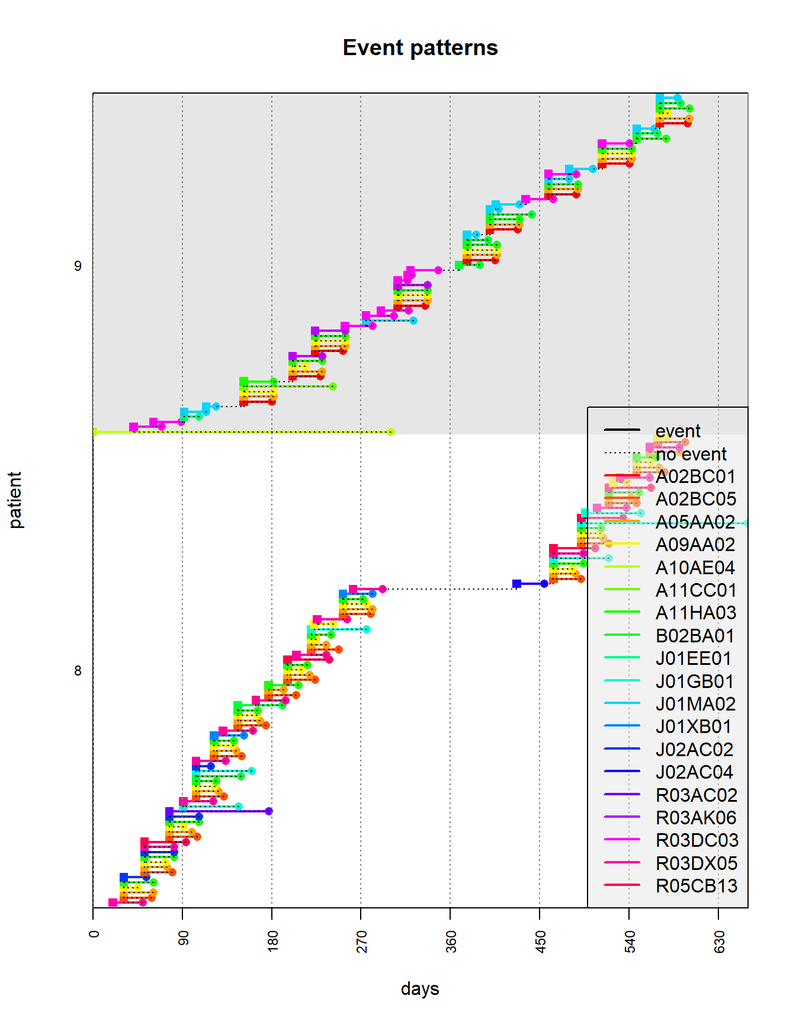

**Figure 1.** Medication histories - two example patients

```r
# Create an object "cma0" of the most basic CMA type, "CMA0":
cma0 <- CMA0(data=event_durations[ID %in% c(8, 9),], # use the two selected patients
             ID.colname="ID", # the name of the column containing the IDs
             event.date.colname="DISP.START", # the name of the column containing the event date
             event.duration.colname="DURATION", # the name of the column containing the duration
             event.daily.dose.colname="DAILY.DOSE", # the name of the column containing the dosage
             medication.class.colname="ATC.CODE"); # the name of the column containing the category
# Plot the object (CMA0 shows the actual event data only):
plot(cma0, # the object to plot
align.all.patients=FALSE); # show timelines relative to the earliest dispensation across patients
```

We can see that these patients have multiple medications, and their dispensation patterns vary substantially during the 2-year FUW. We decide in this example analysis to compute adherence for a single medication class:

```r
# these patients are taking multiple medications in the same time:
table(event_durations$ATC.CODE, exclude=NULL)
```

```
##
## A02BC01 A02BC02 A02BC05 A05AA02 A09AA02 A10AB05 A10AD05 A10AE04 A10BX02
##      26       3      63      55     196      17       2      16      16
## A11CA01 A11CC01 A11CC05 A11HA03   A12AX B02BA01 J01AA08 J01CR02 J01DD13
##      19       1      86     126       9      61      13       2       4
## J01DF01 J01EE01 J01FA10 J01FG01 J01GB01 J01MA02 J01XB01 J02AC02 J02AC03
##       9      37      98       3      29      28      52      49       3
## J02AC04 R03AC02 R03AC12 R03AK06 R03AK07 R03AK08 R03AL04 R03BA05 R03DC03
##       1      47      19      34      27       3       1       7      27
## R03DX05 R05CB13
##      13      59
```

```r
# to compute adherence, we need to select which medication we compute it for
# for example, here we select treatments in the A09A class
med_events_A09 <- event_durations[grepl("^A09A",ATC.CODE),]
```

The plot for the same two patients is now less crowded:

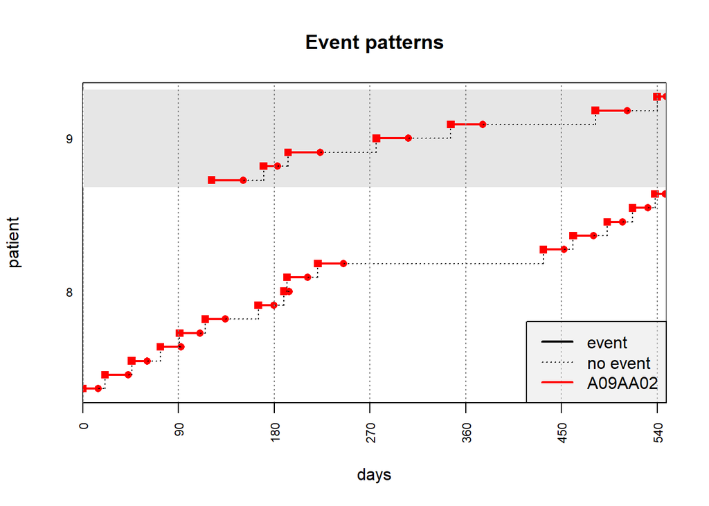

**Figure 2.** Medication histories A09 - two example patients

```r
# Create an object "cma0" of the most basic CMA type, "CMA0":
cma0 <- CMA0(data=med_events_A09[ID %in% c(8, 9),], # use the two selected patients
             ID.colname="ID", # the name of the column containing the IDs
             event.date.colname="DISP.START", # the name of the column containing the event date
             event.duration.colname="DURATION", # the name of the column containing the duration
             event.daily.dose.colname="DAILY.DOSE", # the name of the column containing the dosage
             medication.class.colname="ATC.CODE"); # the name of the column containing the category
# Plot the object (CMA0 shows the actual event data only):
plot(cma0, # the object to plot
align.all.patients=FALSE); # show timelines relative to the earliest dispensation across patients
```

For illustration purposes, let’s calculate a single adherence value over a 3-year FUW. In `AdhereR`, we have 9 CMA (Continuous Multiple Interval Measures of Medication Availability/Gaps) classes that can produce very different estimates of the quality of implementation, the first eight have been described by Vollmer and colleagues (2012) as applied to randomized controlled trials. We implemented them in `AdhereR` based on the authors’ description, and in essence are defined by 4 parameters:

1. how is the OW delimited (whether time intervals before the first event and after the last event are considered),
2. whether CMA values are capped at 100%,
3. whether medication oversupply is carried over to the next event interval, and
4. whether medication available before a first event is considered in supply calculations or OW definition.

We will illustrate here `CMA7`, which is the most complex calculation presented by Vollmer and colleagues. The interested reader may consult the AdhereR vignette for the other CMA versions. Creating an object of class `CMA7` with various parameters automatically performs the estimation of CMA7 for all the patients in the dataset; moreover, the object is smart enough to allow the appropriate printing and plotting. The object includes all the parameter values with which it was created, as well as the `CMA` `data.frame`, which is the main result, with patient ID and the corresponding CMA estimate. The CMA estimates appear as ratios, but can be trivially transformed into percentages and rounded, as we did for patient `8` below (rounded to 2 decimals). The plots show the CMA as percentage rounded to 1 decimal.

```
## [1] 22.58
```

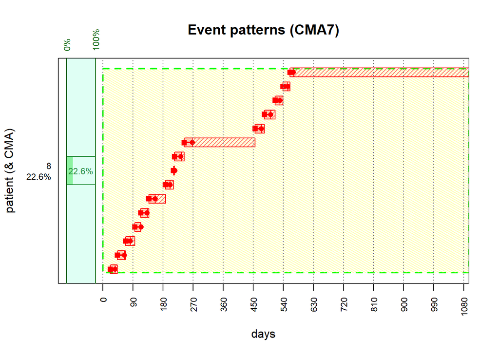

**Figure 3.** Medication history and overall adherence score A09 - patient 8

```r
# Single value per person per observation window

cma7 <- CMA7(med_events_A09,
             ID.colname="ID",
             event.date.colname="DISP.START",
             event.duration.colname="DURATION",
             event.daily.dose.colname="DAILY.DOSE",
             medication.class.colname="ATC.CODE",
             carry.only.for.same.medication=FALSE,
             consider.dosage.change=FALSE,
             followup.window.start="START.PRESC",
             followup.window.duration=3*365,
             observation.window.start=0,
             observation.window.duration=3*365);

plot(cma7,
    patients.to.plot=c("8"),
     show.legend=FALSE);

# CMA transformed into percentage and rounded to 2 decimals
round(cma7$CMA$CMA[cma7$CMA$ID == 8]*100, 2);
```

We can see that if we consider 3 years from the first prescription date patient `8` has a CMA7 of 22.6%, but we see from the plot that adherence varied in time: the medication was dispensed a while after the prescription, there is a gap before the last 5 dispensation, and another after the last dispensing event; there is also a variation in delays to refill during periods of relatively regular dispensing. This suggests that it is important to describe in more detail the stages of adherence (initiation, implementation and non-persistence), and to ensure that the period on which we compute adherence corresponds with the period on which we have data recorded for each patient.

Several other decisions might need to be taken when calculating adherence, which need to be informed by the clinical context of the study:

- what OW is relevant for calculating adherence and persistence?
- is the largest interruption seen in patient `8` an indication of non-persistence, or of lower adherence over that time interval?
- is three switch between different medications of the same class or of different classes, and if so, is this an indicator of a new treatment episode?
- is it necessary to consider carry-over of oversupply from previous events?
- it is necessary to consider carry-over also when medication changes?

These decisions need to be taken based on a good understanding of the pharmacological properties of the medication studied, and the most plausible clinical decision-making in routine care. This information can be collected from an advisory committee with relevant expertise (e.g. based on consensus protocols), or (even better) qualitative or survey research on the routine practices in prescribing, dispensing and using that specific medication. Of course, this is not always possible – a second-best option (or even complementary option, if consensus is not reached) is to compare systematically the effects of different analysis choices on the hypotheses tested (e.g. as sensitivity analyses). `AdhereR` was developped also to allow such comparisons and informed analysis choices.

## Initiation – time_to_initiation

Since we have the date of the prescription start and the date of the first dispensation, we could compute the time to initiation with the `time_to_initiation` function for the patients who had at least one dispensation (non-initiation can be identified in the output of the `compute_event_duration` function, as all rows with missing values in the `DATE.DISP` column are prescribing events that don’t have a corresponding dispensing date).

```r
# the function time_to_initiation calculates the time between the prescription date and the dispensation date, for prescriptions that are dispensed
# Note: for non-initiation, prescriptions which are not dispensed appear as is.na(DATE.DISP) in the output of the compute_event_duration function.


time_init <- time_to_initiation(presc.data = durcomp.prescribing[grepl("^A09A",ATC.CODE),],
                                disp.data = event_durations[!is.na(event_durations$DURATION) & grepl("^A09A",ATC.CODE),],
                                ID.colname = "ID",
                                presc.start.colname = "DATE.PRESC",
                                disp.date.colname = "DATE.DISP",
                                medication.class.colnames = c("ATC.CODE", "FORM", "UNIT"))

# we have now a dataset with a time to initiation per person
str(time_init)
```

```
## 'data.frame':    14 obs. of  7 variables:
##  $ ID                    : num  1 3 4 6 7 8 9 10 11 12 ...
##  $ ATC.CODE              : chr  "A09AA02" "A09AA02" "A09AA02" "A09AA02" ...
##  $ FORM                  : chr  "ORAL FORM" "ORAL FORM" "ORAL FORM" "ORAL FORM" ...
##  $ UNIT                  : chr  "UI" "UI" "UI" "UI" ...
##  $ first.presc           : Date, format: "2056-12-08" "2056-09-23" ...
##  $ first.disp            : Date, format: "2056-12-10" "2056-10-18" ...
##  $ time.to.initialization: num  2 25 25 7 8 22 160 30 0 479 ...
```

```r
summary(time_init$time.to.initialization)
```

```
##    Min. 1st Qu.  Median    Mean 3rd Qu.    Max.
##    0.00    7.25   20.00   58.93   28.75  479.00
```

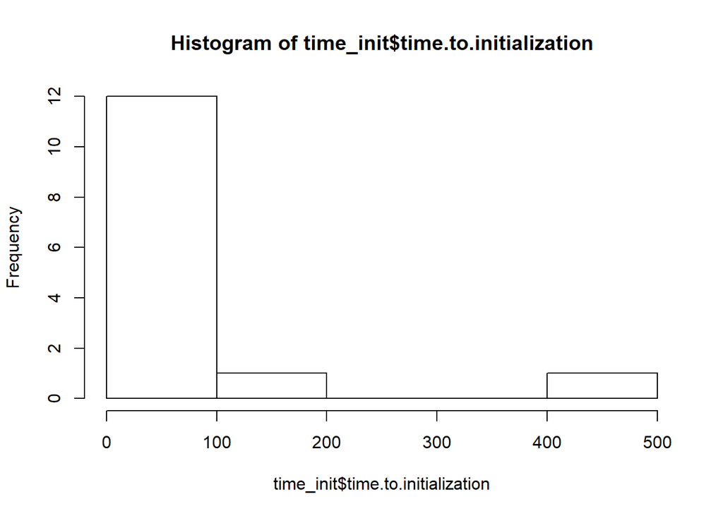

```r
hist(time_init$time.to.initialization)
```

## Persistence – treatment episodes

Once the treatment is dispensed, an important decision is to distinguish between persistence with treatment and quality of implementation. The function `compute.treatment.episodes` was developed for this purpose. We provide below an example of how this function can be used.

Let’s imagine that clinicians in our advisory committee agree that a minumum of 6 months (180 days) need to pass after the end of a medication supply (taken as prescribed) without receiving a new supply in order to be reasonably confident that the patient has discontinued/interrupted the treatment – they can conclude this for example based on an approximate calculation considering that specific medication is usually supplied for 2 month, daily dosage is usually 3 pills a day, and patients often use as low as 1/3 of the recommended dose in a given interval. We will specify this as `maximum.permissible.gap = 180`, and `maximum.permissible.gap.unit = "days"`. (If in another scenario the clinical information we obtain suggests that the permissible gap should depend on the duration of the last supply, for example 6 times that interval should go by before a discontinuation becoming likely, we can specify this as `maximum.permissible.gap = 600`, and `maximum.permissible.gap.unit = "percent"`.)

We might also have some clinical confirmation that usually people finish the existing supply before starting the new one (`carryover.within.obs.window = TRUE`) and take the existing supply based on the new dosage recommendations if these change (`consider.dosage.change = TRUE`).

If `ATC.CODE` included different types of medication and we assumed that whenever a health care professional changes the type of medication supplied this should be considered as a new treatment episode, we would specify this as setting the parameter `medication.change.means.new.treatment.episode` to `TRUE`. Also, if a new type of medication was usually supplied with a recommendation to start a new treatment immediately, we would consider carry-over only for the same medication (`carry.only.for.same.medication = TRUE`). When `ATC.CODE` contains only one medication type these parameters have no impact on the calculation.

The rest of the parameters specify the name of the dataset (here `med_events_A09`), names of the variables in the dataset (here based on the demo dataset, described above), and the FUW (here a 2-year window).

```r
###############
# Persistence #
###############

# this is the function to compute treatment episodes

TEs<- compute.treatment.episodes(med_events_A09,
                                 ID.colname="ID",
                                 event.date.colname="DISP.START",
                                 event.duration.colname="DURATION",
                                 event.daily.dose.colname="DAILY.DOSE",
                                 medication.class.colname="ATC.CODE",
                                 carryover.within.obs.window = TRUE, # carry-over into the OW
                                 carry.only.for.same.medication = TRUE, # not applicable to the example
                                 consider.dosage.change = TRUE, # not applicable to the example
                                  medication.change.means.new.treatment.episode = TRUE, # not applicable to the example
                                  maximum.permissible.gap = 180, # & a gap longer than 180 days
                                  maximum.permissible.gap.unit = "days", # unit for the above (days)
                                  followup.window.start = 0, # 2-years FUW starts at earliest event
                                  followup.window.start.unit = "days",
                                  followup.window.duration = 365 * 2,
                                  followup.window.duration.unit = "days");
# see the first lines of the resulting dataset
head(TEs)
```

```
##   ID episode.ID episode.start end.episode.gap.days episode.duration
## 1  1          1    2056-12-10                  254         285.4419
## 2  1          2    2058-06-03                  137         190.0000
## 3  3          1    2056-10-18                  351         379.0000
## 4  4          1    2057-01-10                  160         730.0000
## 5  6          1    2056-09-22                  100         730.0000
## 6  7          1    2056-12-16                  122         730.0000
##   episode.end
## 1  2057-09-21
## 2  2058-12-10
## 3  2057-11-01
## 4  2059-01-10
## 5  2058-09-22
## 6  2058-12-16
```

```r
# we have now a dataset with several TEs per person, episode duration can be considered as time to discontinuation
# we can summarize the episode duration - the main variable we are interested in, for example in survival analysis (time to event)
summary(TEs$episode.duration)
```

```
##    Min. 1st Qu.  Median    Mean 3rd Qu.    Max.
##    36.0   275.3   638.1   504.0   730.0   730.0
```

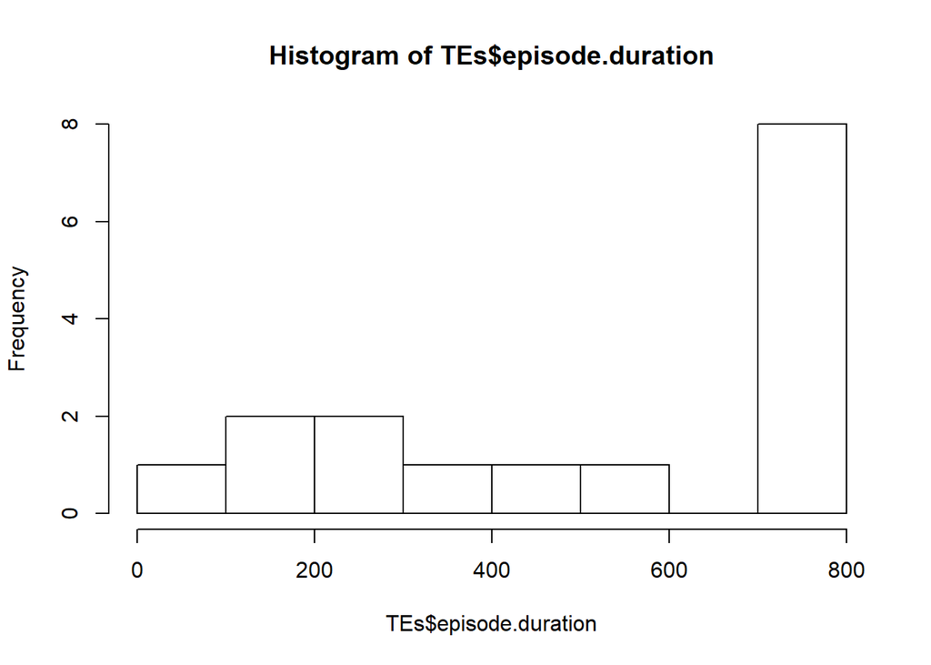

```r
hist(TEs$episode.duration)
```

```r
knitr::kable(TEs,
             caption = "<a name=\"Table-4\"></a>**Table 4.** Example output `compute.treatment.episodes()` function");
```

**Table 4.** Example output `compute.treatment.episodes()` function

| ID | episode.ID | episode.start | end.episode.gap.days | episode.duration | episode.end |
| --- | --- | --- | --- | --- | --- |
| 1 | 1 | 2056-12-10 | 254 | 285.4419 | 2057-09-21 |
| 1 | 2 | 2058-06-03 | 137 | 190.0000 | 2058-12-10 |
| 3 | 1 | 2056-10-18 | 351 | 379.0000 | 2057-11-01 |
| 4 | 1 | 2057-01-10 | 160 | 730.0000 | 2059-01-10 |
| 6 | 1 | 2056-09-22 | 100 | 730.0000 | 2058-09-22 |
| 7 | 1 | 2056-12-16 | 122 | 730.0000 | 2058-12-16 |
| 8 | 1 | 2057-01-17 | 188 | 245.0000 | 2057-09-19 |
| 8 | 2 | 2058-03-26 | 182 | 114.6000 | 2058-07-18 |
| 9 | 1 | 2057-05-18 | 302 | 427.5714 | 2058-07-19 |
| 10 | 1 | 2057-01-07 | 175 | 730.0000 | 2059-01-07 |
| 11 | 1 | 2056-11-12 | 106 | 730.0000 | 2058-11-12 |
| 12 | 1 | 2058-04-22 | 694 | 36.0000 | 2058-05-28 |
| 13 | 1 | 2056-12-24 | 115 | 730.0000 | 2058-12-24 |
| 14 | 1 | 2057-01-16 | 183 | 546.1321 | 2058-07-16 |
| 15 | 1 | 2056-11-17 | 107 | 730.0000 | 2058-11-17 |
| 16 | 1 | 2056-12-05 | 0 | 730.0000 | 2058-12-05 |

The function produces a dataset as the one shown in Table 4. It includes each treatment episode for each patient (here 2 episodes for patient `1`, 1 for patient `3`, etc.) and records the patient ID, episode number, date of episode start, gap days at the end of or after the treatment episode, duration of episode, and episode end date:

- the date of the episode start is taken as the first medication event for a particular medication,
- the end of the episode is taken as the day when the last supply of that medication finished (if a medication change happened, or if a period longer than the permissible gap preceded the next medication event) or the end of the FUW (if no other medication event followed until the end of the FUW),
- the number of end episode gap days represents either the number of days **after** the end of the treatment episode (if medication changed, or if a period longer than the permissible gap preceded the next medication event) or **at** the end of (and within) the episode, i.e. the number of days after the last supply finished (if no other medication event followed until the end of the FUW),
- the duration of the episode is the interval between the episode start and episode end (and may include the gap days at the end, in the latter condition described above).

Notes:

1. just the number of gap days **after** the end of the episode can be computed by keeping all values larger than the permissible gap and by replacing the others by 0,
2. when medication change represents a new treatment episode, the previous episode ends when the last supply is finished (irrespective of the length of gap compared to a maximum permissible gap); any days before the date of the new medication supply are considered a gap. This maintains consistence with the computation of gaps between episodes (whether they are constructed based on the maximum permissible gap rule or the medication change rule).

This output can be used on its own to study causes and consequences of medication persistence (e.g. by using episode duration in time-to-event analyses). This function is also a basis for the `CMA_per_episode` class, which is described later in this tutorial.

## Implementation – continuous multiple interval measures of medication availability/gaps (CMA)

To be able to measure quality of implementation and distinguish it from (non)-persistence, we have three options: either compute an implementation for each treatment episode (using the function `CMA_per_episode`), or select observation windows (OWs) and subsamples of patients that can be characterized as having no treatment interruptions and the compute either one value for the whole period (using the `CMA` function) or multiple values for consecutive (shorter) intervals within the OW (using the `CMA_sliding_window` function).

#### CMA per episode

When we calculated persistence above, we defined only the *treatment episodes*. The `CMA_per_episode` class allows us to define treatment episodes and calculate CMA for each, in one single step. `CMA_per_episode` can compute any of the 9 simple CMAs for all treatment episodes for all patients.

As with the simple CMAs, the `CMA_per_episode` class contains a list that includes all the parameter values, as well as a `CMA` `data.frame` (with all columns of the `compute.treatment.episodes` output table, plus a new column with the CMA values). The `CMA_per_episode` values can also be transformed into percentages and rounded, as we ask you to do for patient `8` below.

```r
##################
# Implementation #
##################

cmaE <- CMA_per_episode(CMA="CMA7", # apply the simple CMA7 to each treatment episode
                        as.data.frame(med_events_A09),
                        ID.colname="ID",
                        event.date.colname="DISP.START",
                        event.duration.colname="DURATION",
                        event.daily.dose.colname="DAILY.DOSE",
                        medication.class.colname="ATC.CODE",
                        carryover.within.obs.window = TRUE,
                        carry.only.for.same.medication = FALSE,
                        consider.dosage.change = FALSE, # conditions on treatment episodes
                        medication.change.means.new.treatment.episode = TRUE,
                        maximum.permissible.gap = 180,
                        maximum.permissible.gap.unit = "days",
                        followup.window.start=0,
                        followup.window.start.unit = "days",
                        followup.window.duration = 365*3,
                        followup.window.duration.unit = "days",
                        observation.window.start=0,
                        observation.window.start.unit = "days",
                        observation.window.duration=365*3,
                        observation.window.duration.unit = "days");
# the output of the function includes several items
str(cmaE);
```

```
## List of 23
##  $ data                            :'data.frame':    196 obs. of  14 variables:
##   ..$ ID                     : num [1:196] 1 1 1 1 1 1 1 1 3 3 ...
##   ..$ ATC.CODE               : chr [1:196] "A09AA02" "A09AA02" "A09AA02" "A09AA02" ...
##   ..$ UNIT                   : chr [1:196] "UI" "UI" "UI" "UI" ...
##   ..$ FORM                   : chr [1:196] "ORAL FORM" "ORAL FORM" "ORAL FORM" "ORAL FORM" ...
##   ..$ TOTAL.DOSE             : num [1:196] 1440000 720000 720000 2940000 1440000 1500000 1500000 4500000 9000000 9000000 ...
##   ..$ DATE.DISP              : Date[1:196], format: "2056-12-10" ...
##   ..$ DISP.START             : Date[1:196], format: "2056-12-10" ...
##   ..$ DURATION               : num [1:196] 40 11 3.77 34.19 16.74 ...
##   ..$ DAILY.DOSE             : num [1:196] 36000 36000 86000 86000 86000 86000 86000 86000 300000 300000 ...
##   ..$ START.PRESC            : Date[1:196], format: "2056-12-08" ...
##   ..$ END.PRESC              : Date[1:196], format: "2057-02-23" ...
##   ..$ HOSP.DURATION          : num [1:196] 0 0 0 3 0 0 0 0 0 0 ...
##   ..$ tot.presc.interruptions: int [1:196] 0 0 0 0 0 0 0 0 0 0 ...
##   ..$ tot.dosage.changes     : num [1:196] 1 1 1 1 1 1 1 1 0 0 ...
##  $ ID.colname                      : chr "ID"
##  $ event.date.colname              : chr "DISP.START"
##  $ event.duration.colname          : chr "DURATION"
##  $ event.daily.dose.colname        : chr "DAILY.DOSE"
##  $ medication.class.colname        : chr "ATC.CODE"
##  $ carryover.within.obs.window     : logi TRUE
##  $ carryover.into.obs.window       : logi TRUE
##  $ carry.only.for.same.medication  : logi FALSE
##  $ consider.dosage.change          : logi FALSE
##  $ followup.window.start           : num 0
##  $ followup.window.start.unit      : chr "days"
##  $ followup.window.duration        : num 1095
##  $ followup.window.duration.unit   : chr "days"
##  $ observation.window.start        : num 0
##  $ observation.window.start.unit   : chr "days"
##  $ observation.window.duration     : num 1095
##  $ observation.window.duration.unit: chr "days"
##  $ date.format                     : chr "%m/%d/%Y"
##  $ summary                         : chr "CMA per treatment episode"
##  $ event.info                      :'data.frame':    14 obs. of  5 variables:
##   ..$ ID             : num [1:14] 1 3 4 6 7 8 9 10 11 12 ...
##   ..$ .FU.START.DATE : Date[1:14], format: "2056-12-10" ...
##   ..$ .FU.END.DATE   : Date[1:14], format: "2059-12-10" ...
##   ..$ .OBS.START.DATE: Date[1:14], format: "2056-12-10" ...
##   ..$ .OBS.END.DATE  : Date[1:14], format: "2059-12-10" ...
##  $ computed.CMA                    : chr "CMA7"
##  $ CMA                             :'data.frame':    16 obs. of  7 variables:
##   ..$ ID                  : num [1:16] 1 1 3 4 6 7 8 8 9 10 ...
##   ..$ episode.ID          : num [1:16] 1 2 1 1 1 1 1 2 1 1 ...
##   ..$ episode.start       : Date[1:16], format: "2056-12-10" ...
##   ..$ end.episode.gap.days: int [1:16] 254 502 716 525 465 487 188 547 667 540 ...
##   ..$ episode.duration    : num [1:16] 285.4 52.3 379 569.3 630 ...
##   ..$ episode.end         : Date[1:16], format: "2057-09-21" ...
##   ..$ CMA                 : num [1:16] 0.492 1 0.554 0.825 0.286 ...
##  - attr(*, "class")= chr "CMA_per_episode"
```

```r
# the CMA estimates table can be called with:
head(cmaE$CMA)
```

```
##   ID episode.ID episode.start end.episode.gap.days episode.duration
## 1  1          1    2056-12-10                  254        285.44186
## 2  1          2    2058-06-03                  502         52.32558
## 3  3          1    2056-10-18                  716        379.00000
## 4  4          1    2057-01-10                  525        569.33333
## 5  6          1    2056-09-22                  465        630.00000
## 6  7          1    2056-12-16                  487        607.28571
##   episode.end       CMA
## 1  2057-09-21 0.4917177
## 2  2058-07-25 1.0000000
## 3  2057-11-01 0.5540897
## 4  2058-08-02 0.8254247
## 5  2058-06-14 0.2857143
## 6  2058-08-15 0.7714756
```

```r
# Note: you will see that 3 treatment episodes consist of a single dispensation: you might decide to exclude these, if you assume that medication initiation requires a second dispensation to attest engagement with the treatment prescribed

# PRACTICAL EXERCISE 3:
# calculate the CMA values for patient 8, rounded at 2 digits:
```

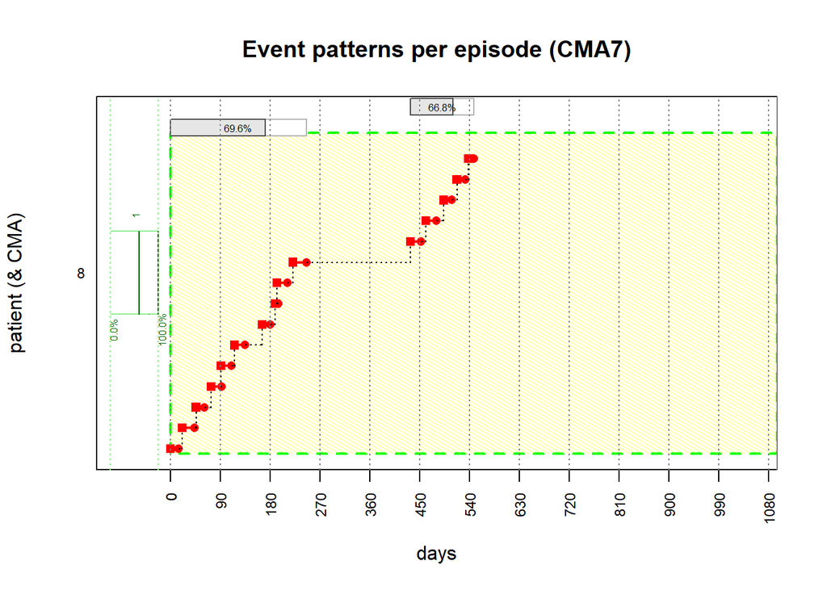

**Figure 4.** CMA per episode - patient 8

```r
plot(cmaE,
     patients.to.plot=c("8"),
     show.legend=FALSE);
```

#### Sliding-window CMA

If patients are dispensing medication regularly (thus having a single treatment episode, like most of the patients in the output of the `compute.treatment.episodes` function above) but the delays in dispensing vary across a 2-year follow-up period, estimating adherence for a 2-year period might be too coarse-grained to be clinically relevant, and that shorter intervals may be more appropriate, for example in studies that aim to investigate how the quality of implementation varies in time during long-term treatment. In such cases, we might want to compare successive intervals, for example 2-month intervals in steps of 1 month. `CMA_sliding_window` allows us to compute any of the 9 simple CMAs for repeated time intervals (*sliding windows*) within an OW. A similar output is produced as for `CMA_per_episode`, including a CMA table (with patient ID, window ID, window start and end dates, and the CMA estimate).

```r
# PRACTICAL EXERCISE 3:
# Exclude from the sample dataset the patients who are not persistent during the 2-year period:



# assuming that all patients were engaged in regular use of medication over a period of 2 years and we have complete data from all sources, we can compute multiple values per patient per observation window

cmaW <- CMA_sliding_window(CMA.to.apply="CMA9",
                           as.data.frame(med_events_A09),
                           ID.colname="ID",
                           event.date.colname="DISP.START",
                           event.duration.colname="DURATION",
                           event.daily.dose.colname="DAILY.DOSE",
                           medication.class.colname="ATC.CODE",
                           carry.only.for.same.medication=FALSE,
                           consider.dosage.change=FALSE,
                           followup.window.start=0,
                           followup.window.duration=2*365,
                           observation.window.start=0,
                           observation.window.duration=2*365,
                           sliding.window.start=0, # sliding windows definition
                           sliding.window.start.unit="days",
                           sliding.window.duration=60,
                           sliding.window.duration.unit="days",
                           sliding.window.step.duration=30,
                           sliding.window.step.unit="days");



# the output of the function includes several items
str(cmaW);
```

```
## List of 30
##  $ data                            :'data.frame':    196 obs. of  14 variables:
##   ..$ ID                     : num [1:196] 1 1 1 1 1 1 1 1 3 3 ...
##   ..$ ATC.CODE               : chr [1:196] "A09AA02" "A09AA02" "A09AA02" "A09AA02" ...
##   ..$ UNIT                   : chr [1:196] "UI" "UI" "UI" "UI" ...
##   ..$ FORM                   : chr [1:196] "ORAL FORM" "ORAL FORM" "ORAL FORM" "ORAL FORM" ...
##   ..$ TOTAL.DOSE             : num [1:196] 1440000 720000 720000 2940000 1440000 1500000 1500000 4500000 9000000 9000000 ...
##   ..$ DATE.DISP              : Date[1:196], format: "2056-12-10" ...
##   ..$ DISP.START             : Date[1:196], format: "2056-12-10" ...
##   ..$ DURATION               : num [1:196] 40 11 3.77 34.19 16.74 ...
##   ..$ DAILY.DOSE             : num [1:196] 36000 36000 86000 86000 86000 86000 86000 86000 300000 300000 ...
##   ..$ START.PRESC            : Date[1:196], format: "2056-12-08" ...
##   ..$ END.PRESC              : Date[1:196], format: "2057-02-23" ...
##   ..$ HOSP.DURATION          : num [1:196] 0 0 0 3 0 0 0 0 0 0 ...
##   ..$ tot.presc.interruptions: int [1:196] 0 0 0 0 0 0 0 0 0 0 ...
##   ..$ tot.dosage.changes     : num [1:196] 1 1 1 1 1 1 1 1 0 0 ...
##  $ ID.colname                      : chr "ID"
##  $ event.date.colname              : chr "DISP.START"
##  $ event.duration.colname          : chr "DURATION"
##  $ event.daily.dose.colname        : chr "DAILY.DOSE"
##  $ medication.class.colname        : chr "ATC.CODE"
##  $ carryover.within.obs.window     : logi TRUE
##  $ carryover.into.obs.window       : logi TRUE
##  $ carry.only.for.same.medication  : logi FALSE
##  $ consider.dosage.change          : logi FALSE
##  $ followup.window.start           : num 0
##  $ followup.window.start.unit      : chr "days"
##  $ followup.window.duration        : num 730
##  $ followup.window.duration.unit   : chr "days"
##  $ observation.window.start        : num 0
##  $ observation.window.start.unit   : chr "days"
##  $ observation.window.duration     : num 730
##  $ observation.window.duration.unit: chr "days"
##  $ date.format                     : chr "%m/%d/%Y"
##  $ summary                         : chr "CMA per sliding window"
##  $ event.info                      :'data.frame':    14 obs. of  5 variables:
##   ..$ ID             : num [1:14] 1 3 4 6 7 8 9 10 11 12 ...
##   ..$ .FU.START.DATE : Date[1:14], format: "2056-12-10" ...
##   ..$ .FU.END.DATE   : Date[1:14], format: "2058-12-10" ...
##   ..$ .OBS.START.DATE: Date[1:14], format: "2056-12-10" ...
##   ..$ .OBS.END.DATE  : Date[1:14], format: "2058-12-10" ...
##  $ computed.CMA                    : chr "CMA9"
##  $ sliding.window.start            : num 0
##  $ sliding.window.start.unit       : chr "days"
##  $ sliding.window.duration         : num 60
##  $ sliding.window.duration.unit    : chr "days"
##  $ sliding.window.step.duration    : num 30
##  $ sliding.window.step.unit        : chr "days"
##  $ sliding.window.no.steps         : logi NA
##  $ CMA                             :'data.frame':    322 obs. of  5 variables:
##   ..$ ID          : num [1:322] 1 1 1 1 1 1 1 1 1 1 ...
##   ..$ window.ID   : int [1:322] 1 2 3 4 5 6 7 8 9 10 ...
##   ..$ window.start: Date[1:322], format: "2056-12-10" ...
##   ..$ window.end  : Date[1:322], format: "2057-02-08" ...
##   ..$ CMA         : num [1:322] 0.625 0.683 0.646 0.569 0.528 ...
##  - attr(*, "class")= chr "CMA_sliding_window"
```

```r
# the CMA estimates table can be called with:
head(cmaW$CMA)
```

```
##   ID window.ID window.start window.end       CMA
## 1  1         1   2056-12-10 2057-02-08 0.6250000
## 2  1         2   2057-01-09 2057-03-10 0.6828604
## 3  1         3   2057-02-08 2057-04-09 0.6461327
## 4  1         4   2057-03-10 2057-05-09 0.5685931
## 5  1         5   2057-04-09 2057-06-08 0.5279117
## 6  1         6   2057-05-09 2057-07-08 0.3214368
```

```r
# we see that this patient had variable adherence during the follow-up period
summary(cmaW$CMA$CMA[cmaW$CMA$ID==7])
```

```
##    Min. 1st Qu.  Median    Mean 3rd Qu.    Max.
##  0.2184  0.4554  0.6988  0.6544  0.8078  1.0000
```

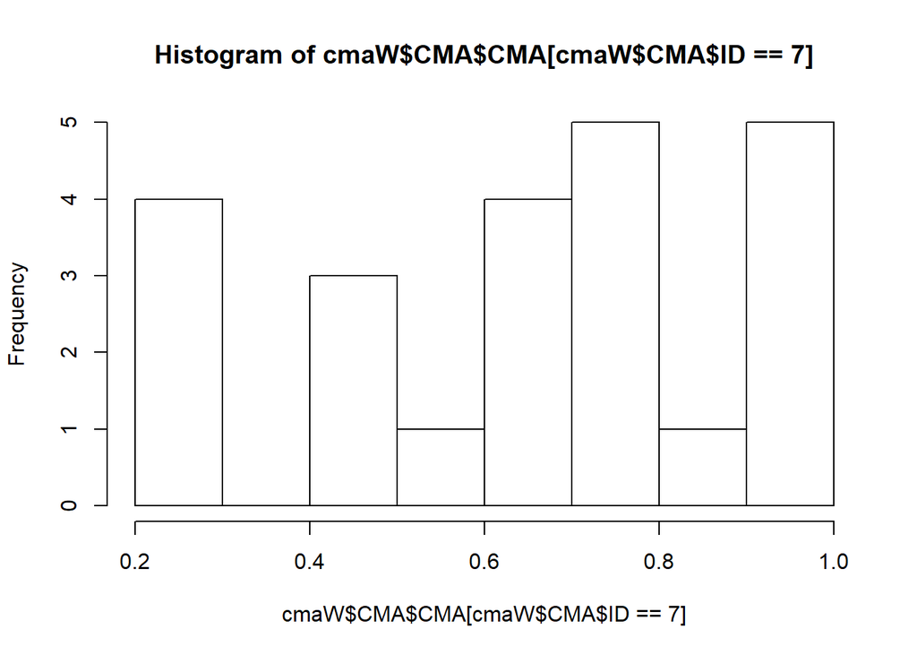

```r
hist(cmaW$CMA$CMA[cmaW$CMA$ID==7])
```

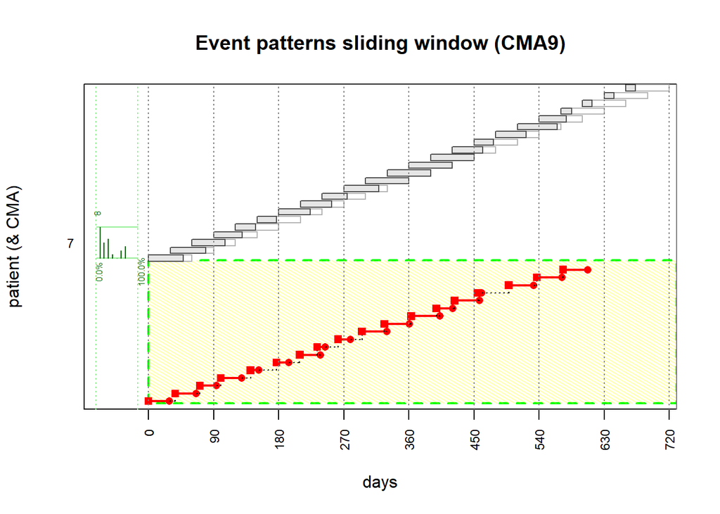

**Figure 5.** CMA sliding window - patient 7

```r
plot(cmaW,
     patients.to.plot=c("7"),
     show.legend=FALSE)
```

Figure 5 shows the results of CMA9 for patient `7`: 23 sliding windows of 2 months, among which some have a CMA of 100%, and some go as low as 21.8%, suggesting a variable quality of implementation.

## Interactive plotting

During the exploratory phases of data analysis, it is sometimes extremely useful to be able to plot interactively various views of the data using different parameter settings. We have implemented such interactive plotting of medication histories and (simple and iterative) CMA estimates within [`RStudio`](https://www.rstudio.com) through the `plot_interactive_cma` function. This function is generic and interactive, and the most important argument is the dataset on which the plotting should be done. Currently, it uses `RStudio`’s `manipulate` library, which means that it only works within `RStudio` and the interface is heavily limited by this library’s capacities. but despite these apparent constraints, it is, nevertheless, a very useful and flexible tool.

After the function was called, the user can select a patient (from a drop-down list of unique patient identifiers present in the dataset), a simple CMA (1 to 9), and can also change various parameters concerning to the FUW, OW, the particular simple CMA, the treatment episodes, or the sliding windows, as appropriate. The effects of these choices are visualized in real time, but depending on the complexity of the computation and on the hardware, this might be more or less instantaneous. An example is given below (please note that you must run this code within `RStudio` and manually select the various parameters.

```r
# Interactive plotting of CMA per-treatment-episode
plot_interactive_cma(data=med_events_A09,
                     cma.class="simple",
                     ID.colname="ID",
                     event.date.colname="DISP.START",
                     event.duration.colname="DURATION",
                     event.daily.dose.colname="DAILY.DOSE",
                     medication.class.colname="ATC.CODE");
```

## References

Arnet I., Kooij M.J., Messerli M., Hersberger K.E., Heerdink E.R., Bouvy M. (2016) [Proposal of Standardization to Assess Adherence With Medication Records Methodology Matters](https://www.ncbi.nlm.nih.gov/pubmed/26917817). *The Annals of Pharmacotherapy* **50**(5):360–8. [doi:10.1177/1060028016634106](http://dx.doi.org/10.1177/1060028016634106).

Peterson A.M., Nau D.P., Cramer J.A., Benner J., Gwadry-Sridhar F., Nichol M. (2007) [A checklist for medication compliance and persistence studies using retrospective databases](https://www.ncbi.nlm.nih.gov/pubmed/17261111). *Value in Health: Journal of the International Society for Pharmacoeconomics and Outcomes Research* **10**(1):3–12. [doi:10.1111/j.1524-4733.2006.00139.x](http://dx.doi.org/10.1111/j.1524-4733.2006.00139.x).

Vollmer W.M., Xu M., Feldstein A., Smith D., Waterbury A., Rand C. (2012) [Comparison of pharmacy-based measures of medication adherence](https://www.ncbi.nlm.nih.gov/pubmed/22691240). *BMC Health Services Research* **12**(1):155. [doi:10.1186/1472-6963-12-155](http://dx.doi.org/10.1186/1472-6963-12-155).